# Practical Machine Learning - JHU

Peter Vennel

October 24, 2015

## Introduction

**George Box: All models are wrong. But some are useful!**

This project is part of Practical Machine Learning course from Johns Hopkins University. Here I am expected to come up with a predictive model from data provided using machine learning techniques.

Six young health participants were asked to perform one set of 10 repetitions of the Unilateral Dumbbell Biceps Curl in five different fashions:

- Class A -> Exactly according to the specification.
- Class B -> Throwing the elbows to the front.
- Class C -> Lifting the dumbbell only halfway.
- Class D -> Lowering the dumbbell only halfway.
- Class E -> Throwing the hips to the front.

Class A corresponds to the specified execution of the exercise, while the other 4 classes correspond to common mistakes.

My goal is to use data from accelerometers on the belt, forearm, arm, and dumbell of these 6 participants and predict the manner in which they did the exercise.

For more information about the data please visit the HAR project at http://groupware.les.inf.puc-rio.br/har

**Note:** To keep the main report concise, I have moved all code and detail results to Appendix.

## Exploratory Data Analysis

I performed some initial exploration of the data to get a better understanding of what we are dealing with. The following are the results of the EDA

1. The data set has 19622 observations of 160 Variables.
2. There were irrelevant data like “”, “#DIV/0!”.
3. Lot of variables had NA or irrelevant data.
4. There were some variables which could be filtered out, because it would not add any value to the predictive model. These variables were X, user_name, raw_timestamp_part_1, raw_timestamp_part_2, cvtd_timestamp, new_window and num_window.

(See Appendix A1 for details)

**Pre-processing**

1. Replace all “” and “#DIV/0!” values with “NA”.
2. Filter our variables with more that 19000 observation with value = “NA”.
3. Filter out the 7 variables that are irrevalent to the calculation.
4. So we now have 19622 observations with 53 variables.

**Data Slicing**

We create the **training** and **testing** data with split of 0.7 . So we will end up with to datasets. We will build our model using **training** data set and then validate the predictive model using the **testing** data. (See Appendix A2 for details)

## Model Comparison

This is the most interesting part. We are not sure what model method will be the most effective. (See Appendix A3 for details)

I have used the following 4 model types:

[output not shown]

First we fit the 4 models using the training dataset. Then we k-fold cross validation, using 10 folds. Once the models are trained and an optimal parameter configuration found for each, the accuracy results from each of the best models are collected. Each ???winning??? model has 30 results (3 repeats of 10-fold cross validation). The objective of comparing results is to compare the accuracy distributions (30 values) between the models.

The distributions are summarized in terms of the percentiles. (see Appendix A3 for table of results). I have also created a Box plot comparing model results (see Appendx A3).

Clearly from the above 4 models, we see that Random Forest is more effective and accurate.

Building models using **train** takes more time and has less options to tune. We will now directly use the randomForest package so we can configure the parameters and further tune the model (did I say faster…).

## Final Model Fitting

I will now use **randomForest** package. See the **confusionMatrix()** result (in Appendix A4). We now get accuracy of **99.66%**. Now looking at the **varImplPlot()** result (See Appendix A4 for details), I could identify which variables are important. This helps us in reducing the variables without reducing the quality of the model.

## Conclusion

Random forest runtimes are quite fast, and they are able to deal with unbalanced and missing data. Random Forest weaknesses are that when used for regression they cannot predict beyond the range in the training data, and that they may over-fit data sets that are particularly noisy. In our case the training data is very good, which helped with machine learning algorithm.

In random forests, there is no need for cross-validation or a separate test set to get an unbiased estimate of the test set error. It is estimated internally, during the run. Based on the model training, we can say that out of sample error to be **0.49%**.

Also, running this model on the test data for submission, I got a **100%** success rate. But that does not guarantee that the model is perfect and flawless. In addition the quality of the machine prediction algorithm depends on the quality of the **classe** variable value. This is used to learn to predict new data.

However, when a machine learning algorithm shows an implausible good fit (99%+ accuracy), it can be a symptom that you don’t have enough training data to falsify bad modeling alternatives.

## Future Work

I must admit that I am still a novice in the model world and do not have a thorough understanding of all the various hundreds of models. While Random Forest came out as the the front runner among other 3 models I choose, I believe there might be other models that might perform equally good if not better to Random Forest. For this I need to investigate more into the various Machine Learning Algorithm to see which ones work better in which situations.

## Appendix

**A1: Loading the data**

```r
library(caret)
library(randomForest)
library(mlbench)

set.seed(1234)

pml_training <- read.csv("data/pml-training.csv", na.strings=c("NA", "#DIV/0!", ""))

table(pml_training$classe)
```

```
##
##    A    B    C    D    E
## 5580 3797 3422 3216 3607
```

```r
na_count <- sapply(pml_training, function(y) sum(length(which(is.na(y)))))
y1 <- data.frame(na_count)
naCols <- cbind(rownames(y1),y1)
names(naCols) <- c('ColNames', 'RowCount')
y3 <- naCols[naCols$RowCount > 19000,]

NAColsNames <- as.character(y3$ColNames)
delCols <- names(pml_training)%in% NAColsNames
pml_trainingNonNA <- pml_training[!delCols]
pml_trainingNonNA <- pml_trainingNonNA[c(-1,-2,-3,-4,-5,-6,-7)]
```

**A2: Cross Validation**

```r
inTrain <- createDataPartition(y=pml_trainingNonNA$classe,
                               p = 0.7, list=FALSE)
training <- pml_trainingNonNA[inTrain,]
testing <- pml_trainingNonNA[-inTrain,]
```

**A3: Model Comparison**

```r
#Since these models take time to build, I saved it the first time and loading them.

# prepare training scheme
# Repeated k-fold Cross Validation - 10 fold
control <- trainControl(method="repeatedcv", number=10, repeats=3, classProbs = TRUE)

#modlda <- train(classe ~ ., data=training, method="lda",  trControl=control)
#saveRDS(modlda, "modlda.rds")
modlda <- readRDS("modlda.rds")

#modrpart  <- train(classe ~ ., data=training, method="rpart",  trControl=control)
#saveRDS(modrpart, "modrpart.rds")
modrpart <- readRDS("modrpart.rds")

#modrf  <- train(classe ~ ., data=training, method="rf", trControl=control)
#saveRDS(modrf, "modrf.rds")
modrf <- readRDS("modrf.rds")

#modsvm  <- train(classe ~ ., data=training, method="svmRadial", trControl=control)
#saveRDS(modsvm, "modsvm.rds")
modsvm <- readRDS("modsvm.rds")
```

```r
# collect resamples
results <- resamples(list(LDA=modlda, RPART=modrpart, RF=modrf, SVM=modsvm))
# summarize the distributions
summary(results)
```

```
##
## Call:
## summary.resamples(object = results)
##
## Models: LDA, RPART, RF, SVM
## Number of resamples: 30
##
## Accuracy
##         Min. 1st Qu. Median   Mean 3rd Qu.   Max. NA's
## LDA   0.6749  0.6951 0.7033 0.7019  0.7119 0.7232    0
## RPART 0.4840  0.5066 0.5309 0.5294  0.5481 0.5779    0
## RF    0.9898  0.9907 0.9927 0.9929  0.9947 0.9978    0
## SVM   0.7840  0.7967 0.8045 0.8027  0.8082 0.8188    0
##
## Kappa
##         Min. 1st Qu. Median   Mean 3rd Qu.   Max. NA's
## LDA   0.5876  0.6138 0.6247 0.6228  0.6352 0.6497    0
## RPART 0.3261  0.3562 0.3993 0.3975  0.4320 0.4712    0
## RF    0.9871  0.9883 0.9908 0.9910  0.9933 0.9972    0
## SVM   0.7253  0.7414 0.7515 0.7491  0.7559 0.7696    0
```

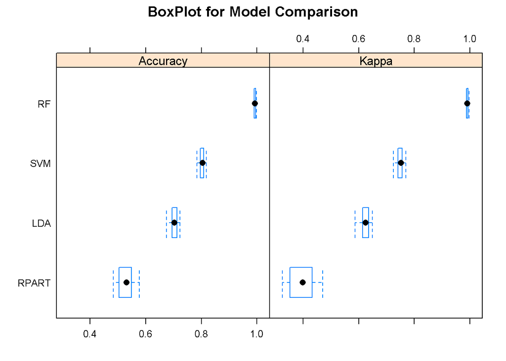

```r
# boxplots of results
bwplot(results, main="BoxPlot for Model Comparison")
```

**A4: Model Fitting**

```r
modrfDirect <- randomForest(classe ~ ., data=training, ntree=1000, importance=TRUE)
confusionMatrix(predict(modrfDirect,testing), testing$classe)
```

```
## Confusion Matrix and Statistics
##
##           Reference
## Prediction    A    B    C    D    E
##          A 1674    7    0    0    0
##          B    0 1131    6    0    0
##          C    0    1 1020    4    0
##          D    0    0    0  959    1
##          E    0    0    0    1 1081
##
## Overall Statistics
##
##                Accuracy : 0.9966
##                  95% CI : (0.9948, 0.9979)
##     No Information Rate : 0.2845
##     P-Value [Acc > NIR] : < 2.2e-16
##
##                   Kappa : 0.9957
##  Mcnemar's Test P-Value : NA
##
## Statistics by Class:
##
##                      Class: A Class: B Class: C Class: D Class: E
## Sensitivity            1.0000   0.9930   0.9942   0.9948   0.9991
## Specificity            0.9983   0.9987   0.9990   0.9998   0.9998
## Pos Pred Value         0.9958   0.9947   0.9951   0.9990   0.9991
## Neg Pred Value         1.0000   0.9983   0.9988   0.9990   0.9998
## Prevalence             0.2845   0.1935   0.1743   0.1638   0.1839
## Detection Rate         0.2845   0.1922   0.1733   0.1630   0.1837
## Detection Prevalence   0.2856   0.1932   0.1742   0.1631   0.1839
## Balanced Accuracy      0.9992   0.9959   0.9966   0.9973   0.9994
```

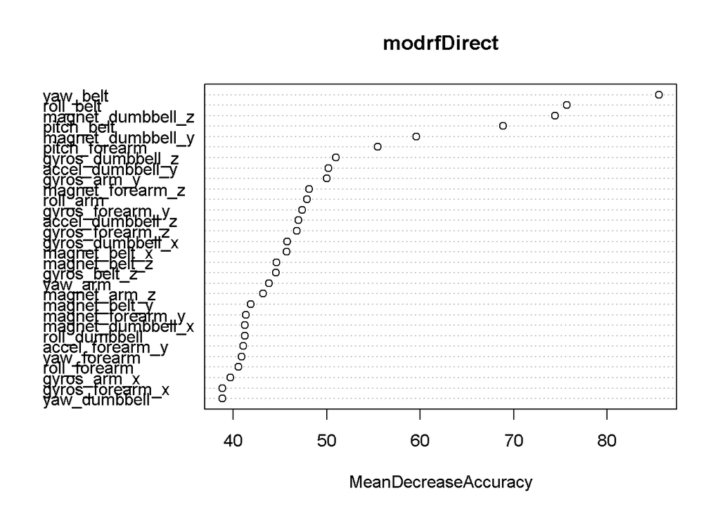

```r
varImpPlot(modrfDirect, type=1)
```

**A5: Fitting the model with fewer variables**

```r
selVars <- c("classe","yaw_belt", "roll_belt", "magnet_dumbbell_z", "pitch_belt", "magnet_dumbbell_y", "pitch_forearm", "gyros_arm_y", "magnet_belt_x", "roll_arm", "gyros_dumbbell_z", "gyros_dumbbell_x", "accel_dumbbell_y", "gyros_forearm_z", "magnet_forearm_z", "accel_dumbbell_z", "roll_forearm", "gyros_belt_z", "gyros_forearm_y", "roll_dumbbell", "yaw_dumbbell", "accel_belt_z", "yaw_arm", "magnet_belt_z", "yaw_forearm", "accel_forearm_z", "magnet_forearm_y", "magnet_dumbbell_x", "accel_forearm_y", "magnet_arm_z", "magnet_belt_y")
trainingNew <- training[, selVars]
modrfDirectNew <- randomForest(classe ~ ., data=trainingNew, ntree=1000, importance=TRUE)

modrfDirectNew
```

```
##
## Call:
##  randomForest(formula = classe ~ ., data = trainingNew, ntree = 1000,      importance = TRUE)
##                Type of random forest: classification
##                      Number of trees: 1000
## No. of variables tried at each split: 5
##
##         OOB estimate of  error rate: 0.49%
## Confusion matrix:
##      A    B    C    D    E  class.error
## A 3903    2    0    0    1 0.0007680492
## B   13 2638    7    0    0 0.0075244545
## C    0    9 2381    6    0 0.0062604341
## D    0    0   18 2233    1 0.0084369449
## E    0    0    2    8 2515 0.0039603960
```

**A6: Final Model testing**

```r
confusionMatrix(predict(modrfDirectNew,testing), testing$classe)
```

```
## Confusion Matrix and Statistics
##
##           Reference
## Prediction    A    B    C    D    E
##          A 1674    7    0    0    0
##          B    0 1131    5    0    0
##          C    0    1 1017    4    0
##          D    0    0    4  960    3
##          E    0    0    0    0 1079
##
## Overall Statistics
##
##                Accuracy : 0.9959
##                  95% CI : (0.9939, 0.9974)
##     No Information Rate : 0.2845
##     P-Value [Acc > NIR] : < 2.2e-16
##
##                   Kappa : 0.9948
##  Mcnemar's Test P-Value : NA
##
## Statistics by Class:
##
##                      Class: A Class: B Class: C Class: D Class: E
## Sensitivity            1.0000   0.9930   0.9912   0.9959   0.9972
## Specificity            0.9983   0.9989   0.9990   0.9986   1.0000
## Pos Pred Value         0.9958   0.9956   0.9951   0.9928   1.0000
## Neg Pred Value         1.0000   0.9983   0.9981   0.9992   0.9994
## Prevalence             0.2845   0.1935   0.1743   0.1638   0.1839
## Detection Rate         0.2845   0.1922   0.1728   0.1631   0.1833
## Detection Prevalence   0.2856   0.1930   0.1737   0.1643   0.1833
## Balanced Accuracy      0.9992   0.9960   0.9951   0.9972   0.9986
```